# Lab 4: Spatial Predictive Analysis

Analyzing ‘Alley Lights Out’ 311 Violation

Author

Umair Bin Saad

Published

April 3, 2026

## My Objectives

In this assignment, my objective is to apply the spatial predictive modeling techniques learned in class to a new 311 service request type, specifically Alley Lights Out. I aim to adapt the provided example code to analyze this dataset, create meaningful spatial features, and use appropriate count regression models to examine burglary incidents as the outcome variable, while incorporating Alley Lights Out as a key spatial predictor along with other spatial features. Additionally, I seek to implement spatial cross-validation to evaluate model performance, interpret the results clearly, and critically assess how well the model explains the spatial distribution of burglary across Chicago.

“I have selected the 311 service request type ‘Alley Lights Out’ as Violation type for this analysis becasue it interests me. This violation type focuses on reports of non-functioning alley lighting, which is important for public safety and urban infrastructure maintenance. It differs from the abandoned cars example covered in class and provides a meaningful basis for exploring spatial patterns and building a predictive model.

- Total Number of calls = 218912

### Data Loading & Exploration

The required datasets have been successfully loaded, including the 311 service request data for ‘Alley Lights Out’, as well as the spatial boundary layers for Chicago city limits, police districts, and police beats. These datasets will be used to explore spatial patterns and support further analysis. burglaries data has also been loaded here.

- Police districts: 25
- Police beats: 277
- Number of burglaries: 7482
- CRS: ESRI:102271

The spatial distribution of the ‘police districts’ violation type has been created and is shown below.

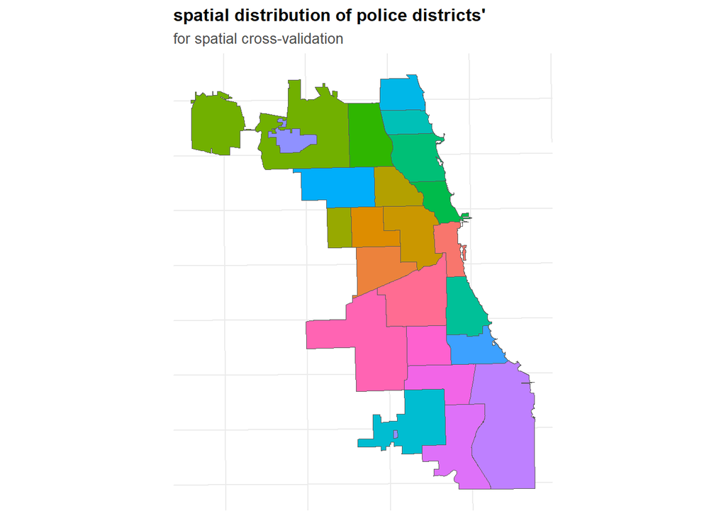

The spatial distribution of the ‘police Beats’ violation type has been created and is shown below.

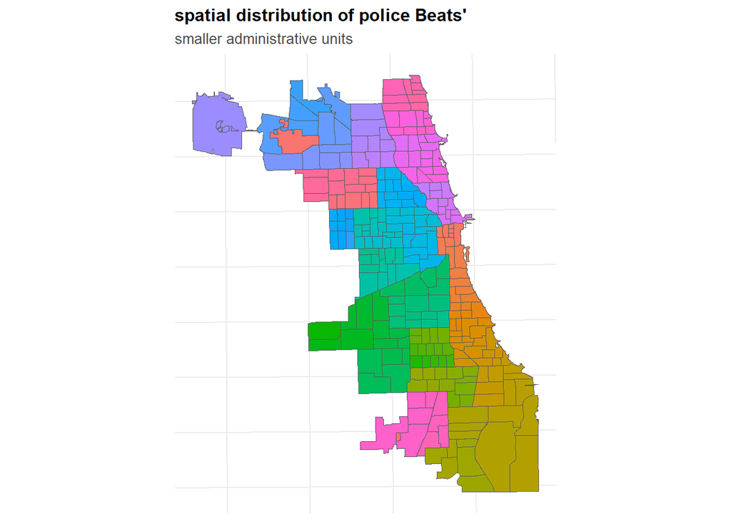

The outline/boundary of the Chicago has been created and is shown below.

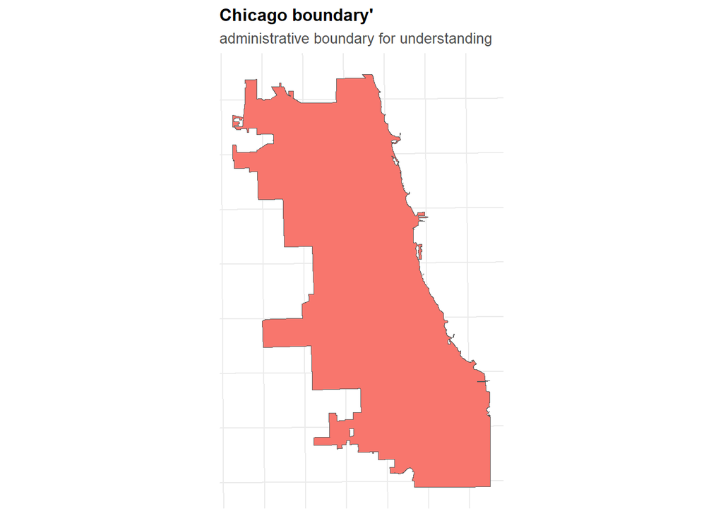

The spatial distribution of the ‘Alley Lights Out’ violation type has been created and is shown below.

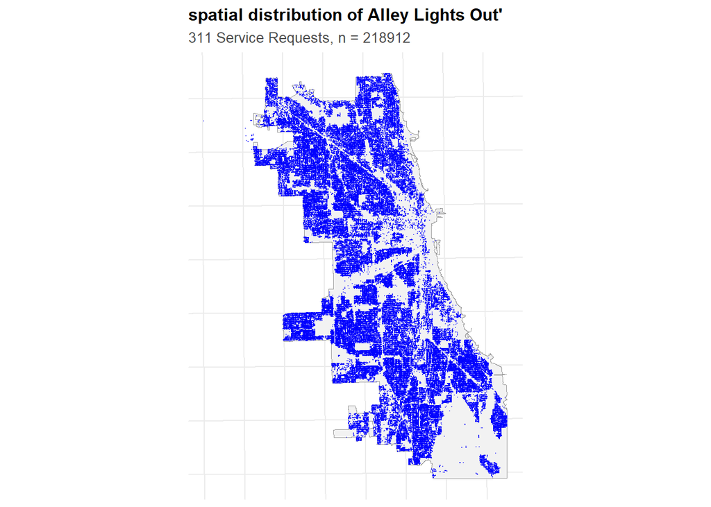

### Fishnet Grid

A 500m x 500m fishnet grid has been successfully created for the study area. The grid consists of 2,458 cells, with each cell measuring 500 x 500 meters and covering an area of 250,000 square meters. These grid cells will be used as the spatial units for further analysis and modeling. Wee only Kept cells that intersect within Chicago bondary.

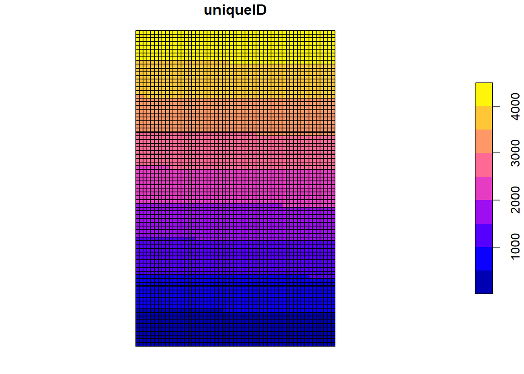

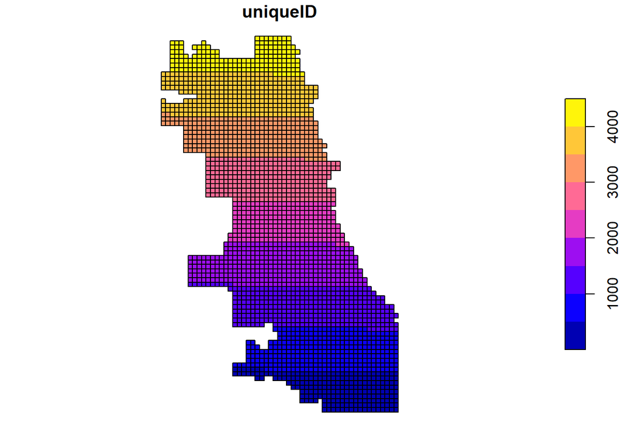

### Aggregation of Alley Lights Out Violations to Fishnet Grid:

The selected 311 violation type, ‘Alley Lights Out’, has been successfully aggregated to the fishnet grid by counting the number of violations within each cell. Out of the total 2,458 grid cells, 362 cells (14.7%) contain zero Alley Lights Out violations, while 2,096 cells have at least one recorded violation, indicating that most areas experienced some level of reported outages.”

### Aggregation of Burglary Incidents to Fishnet Grid

The burglary incidents have also been aggregated to the same fishnet grid by counting the number of burglaries within each cell (countBurglaries). Out of the total 2,458 grid cells, 781 cells (31.8%) contain zero burglary incidents, while 1,677 cells have at least one recorded burglary. Compared to the Alley Lights Out violations (which had only 14.7% zero cells), burglary incidents are more sparsely distributed across the study area.

### Visualize the count distribution of ‘Alley Lights Out’

This figure shows the spatial distribution of “Alley Lights Out” complaints across Chicago using a 500m × 500m fishnet grid. Each grid cell is colored based on the number of reported complaints, with lighter (yellow) areas indicating higher counts and darker (purple) areas indicating fewer or no reports. The map reveals clear spatial clustering, where certain neighborhoods—particularly in parts of the central and southern areas—experience higher concentrations of outage complaints. This suggests that alley light issues are not randomly distributed, but instead complaints are reported more frequently in specific locations, possibly due to infrastructure conditions or neighborhood characteristics.

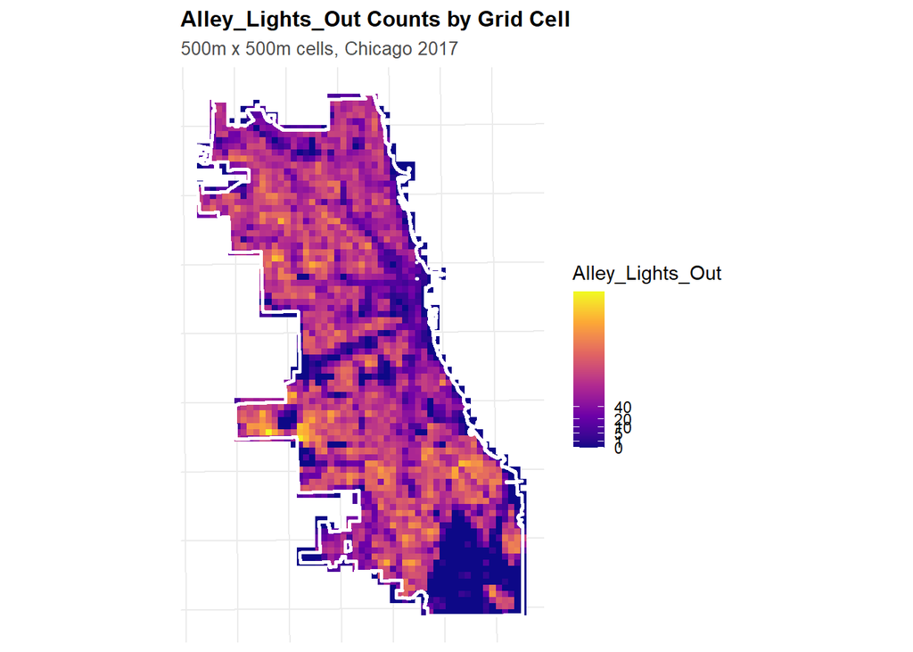

### Visualize the count distribution of Burglary

This figure shows the spatial distribution of burglary incidents across Chicago using a 500m × 500m fishnet grid. Each grid cell is shaded based on the number of reported burglaries, with lighter (yellow) areas indicating higher counts and darker (purple) areas indicating fewer or no incidents. The map highlights clear spatial clustering of burglary incidents, with certain areas—particularly parts of the central and southern regions—experiencing higher concentrations of burglaries. This pattern suggests that burglary is not randomly distributed across the city, but is instead more prevalent in specific locations, potentially influenced by factors such as neighborhood characteristics, land use, or socio-economic conditions.

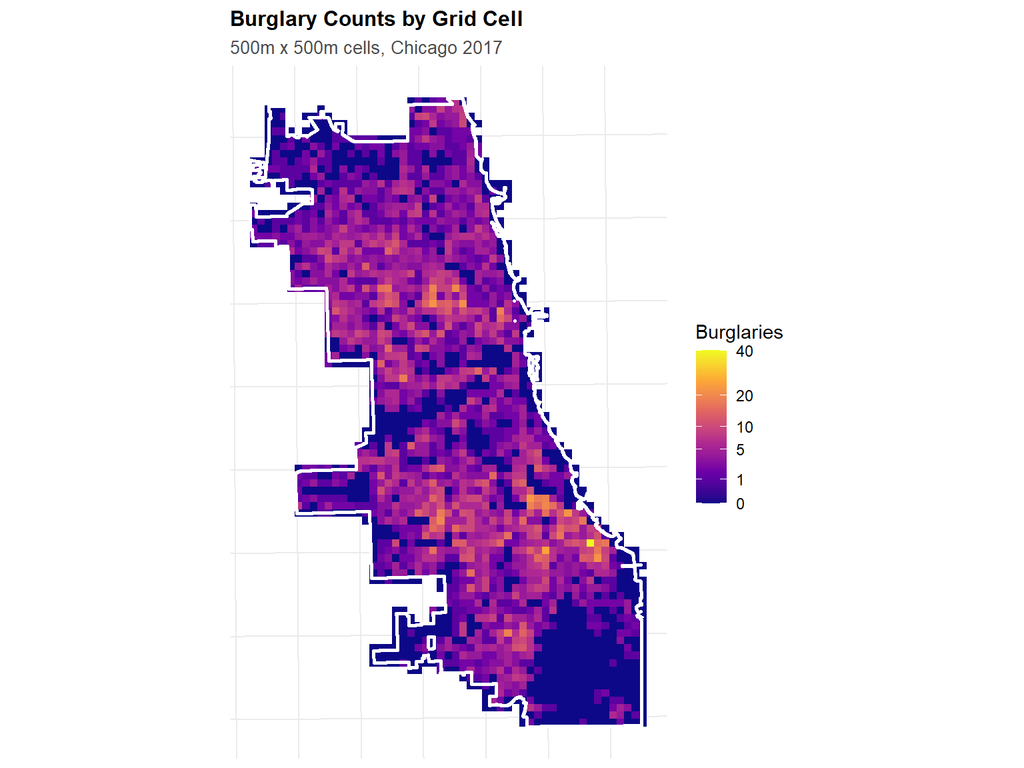

## k-nearest neighbors

In this step, spatial features were generated by calculating k-nearest neighbor distances to capture the local context of incidents. In addition to counting the number of events within each grid cell, the distance to the nearest three neighboring incidents was computed to better understand spatial relationships. The results show that the nearest neighbor distances vary considerably across the study area, with a minimum distance of 2.711 meters, a median of 68.830 meters, and a mean distance of 169.671 meters, indicating moderate clustering in some regions and wider spacing in others. The maximum distance of 1706.739 meters suggests that some cells are relatively isolated, highlighting spatial variability in the distribution of incidents.

### Local Moran’s I analysis

- Let’s identify clusters of Alley Lights Out using Local Moran’s I, then calculate distance to these hot spots. First identification of hot spots and cold spots

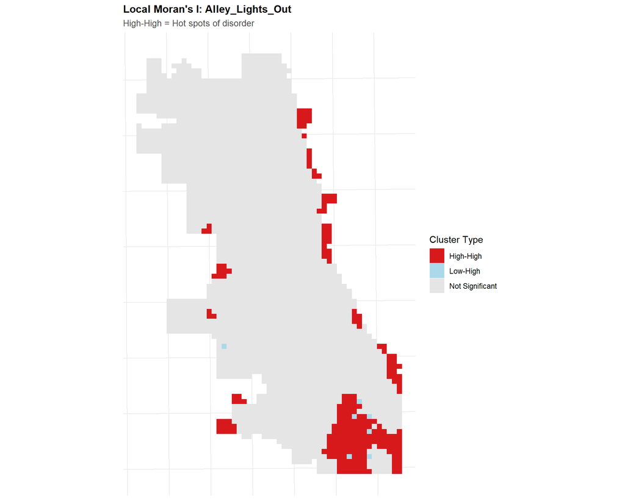

### Distance-to-hotspot measures

The results indicate that 235 grid cells have been identified as hotspot areas for Alley Lights Out complaints. This means there are a substantial number of locations where high levels of complaints are spatially clustered together. The presence of these hotspots confirms that outage complaints are not randomly distributed, but instead concentrated in specific parts of the city. Additionally, calculating the distance from each grid cell to the nearest hotspot provides an important spatial measure of proximity, showing how close or far different areas are from these high-complaint zones. Overall, this result highlights the existence of localized problem areas and supports the use of spatial features in predicting and understanding patterns of alley light outage complaints.

## Joinned Police Districts for Cross-Validation

We are using police districts for our spatial cross-validation.

This step integrates police district boundaries with the fishnet grid to support spatial cross-validation. As a result, 22 police districts are included in the analysis, and 1,708 grid cells fall within these districts. This ensures that only relevant spatial units within official administrative boundaries are used for modeling. The outcome is important because it allows the analysis to be structured around real-world geographic divisions, improving the reliability of model evaluation and making the results more meaningful for policy and resource allocation decisions.

# Count Regression Models

- Fit Poisson regression

  A Poisson regression model was fitted to analyze burglary incidents, as burglary counts represent discrete count data (e.g., 0, 1, 2, 3…). The modeling dataset consisted of 1,708 observations, corresponding to the grid cells within police districts, and included 6 variables capturing relevant spatial features. This approach allows for estimating how different spatial factors are associated with variations in burglary counts across the study area.

## Check for Overdispersion

Poisson regression assumes mean = variance. Real count data often violates this (over dispersion).

### Results

Dispersion parameter: 3.07  
Rule of thumb: >1.5 suggests overdispersion  
Overdispersion detected! Consider Negative Binomial model.

### Now we will use Fit Negative Binomial regression

(Dispersion parameter for Negative Binomial(1.7868)

Model Comparison:  
Poisson AIC: 8788.4  
Negative Binomial AIC: 7401.9

The Poisson regression model initially showed a dispersion parameter of 3.07, which is greater than the rule-of-thumb threshold of 1.5, indicating overdispersion in the data. This means that the variability in burglary counts is higher than what the Poisson model assumes, making it less appropriate for this analysis. To address this issue, a Negative Binomial model was fitted, which is better suited for overdispersed count data. Comparing the two models using AIC (where lower values indicate better fit), the Negative Binomial model (AIC = 7401.9) performs substantially better than the Poisson model (AIC = 8788.4). This comparison suggests that the Negative Binomial model provides a more accurate and reliable representation of the burglary data, and is therefore the preferred model for this analysis.

### Spatial Cross-Validation (2017)

Implement Leave-One-Group-Out cross-validation on 2017 data  
Mean MAE: 2.47  
Mean RMSE: 3.4

## Generate Final Predictions

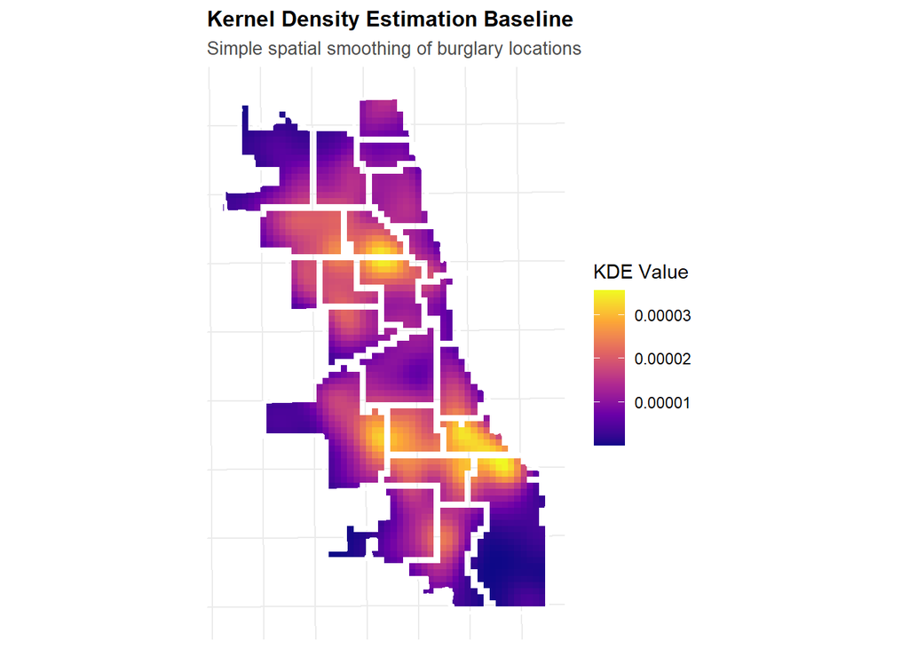

This figure shows the Kernel Density Estimation (KDE) baseline for burglary incidents in Chicago, which represents a smoothed surface of burglary locations. Instead of showing exact counts per grid cell, the KDE map highlights the intensity or concentration of burglary incidents across space. Areas shown in lighter colors (yellow) indicate locations with a higher density of burglaries, while darker areas (purple) represent lower density. The map reveals clear hotspot regions, particularly in parts of the central and southern areas, where burglaries are more concentrated. This visualization serves as a baseline model, helping to identify general spatial patterns of crime without incorporating additional predictors, and provides a useful comparison for evaluating the performance of more advanced predictive models.

## Model Evaluation

Comparison to KDE baseline

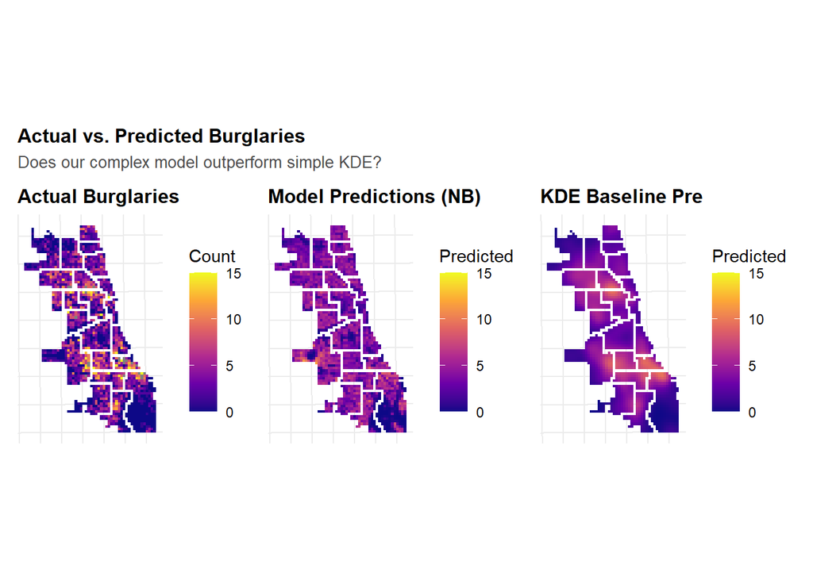

This figure compares actual burglary counts, predictions from the Negative Binomial model, and the KDE baseline predictions to evaluate model performance. The first map shows the observed distribution of burglaries across grid cells, while the second map presents the model’s predicted counts using spatial features such as Alley Lights Out and hotspot distances. The third map shows predictions from the simpler KDE approach, which only captures general spatial intensity.

Model Performance Comparison

| model_mae | model_rmse | kde_mae | kde_rmse |
| --- | --- | --- | --- |
| 2.376997 | 3.491495 | 2.057949 | 2.949266 |

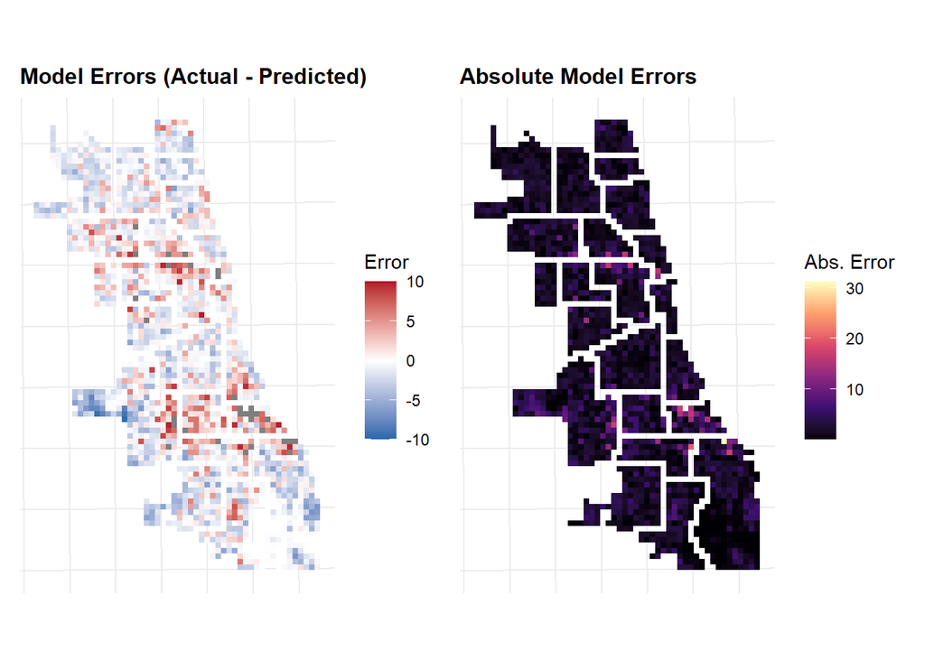

The picture compares two maps showing how accurate a burglary prediction model is across different areas. The first map shows whether the model predicted too many or too few burglaries. Blue regions mean the model predicted more burglaries than actually happened, while red regions mean it predicted fewer burglaries than occurred. White areas show places where the prediction was close to correct. The second map focuses only on how large the prediction mistakes are. Dark colors represent small errors, while brighter colors represent larger errors. Together, the two maps show both the direction and the size of the model’s mistakes, helping identify which areas are predicted well and which areas need improvement.